# Peer Assignment 2

This R Markdown document was created for Peer Assignment 2 for the COursera class Reproducible Research.

# Synopsis

This report utilizes theU.S. National Oceanic and Atmospheric Administration’s (NOAA) storm database to analyze some characteritics of major weather-related events. After analyzing these data we found the following important characteristics:

1. Across the US Tornado is by far the most dangerous weather-related event causing the most injuries and fatalities. The next most dangerous events are Heat, Flood, and Lightning in that order.
2. Across the US the most economically damaging weather-related event (as it relates to both property and crop damage) is Flooding. The next most economically impactful events are Hurricane, Tornado, and Storm Surge in that order.

## Processing the Data

The first step is to read the data (“repdata-data-StormData.csv”) into R. The following code will acomplish this. Make sure that the data exists and is unzipped into your working directory. Once we read the data, we will also view the first few rows to get a sense of how the data is structured and make sure that it was read properly.

```r
weather_data <- read.table("repdata-data-StormData.csv", header=TRUE, sep=",")
head(weather_data, 3)
```

```
##   STATE__          BGN_DATE BGN_TIME TIME_ZONE COUNTY COUNTYNAME STATE
## 1       1 4/18/1950 0:00:00     0130       CST     97     MOBILE    AL
## 2       1 4/18/1950 0:00:00     0145       CST      3    BALDWIN    AL
## 3       1 2/20/1951 0:00:00     1600       CST     57    FAYETTE    AL
##    EVTYPE BGN_RANGE BGN_AZI BGN_LOCATI END_DATE END_TIME COUNTY_END
## 1 TORNADO         0                                               0
## 2 TORNADO         0                                               0
## 3 TORNADO         0                                               0
##   COUNTYENDN END_RANGE END_AZI END_LOCATI LENGTH WIDTH F MAG FATALITIES
## 1         NA         0                      14.0   100 3   0          0
## 2         NA         0                       2.0   150 2   0          0
## 3         NA         0                       0.1   123 2   0          0
##   INJURIES PROPDMG PROPDMGEXP CROPDMG CROPDMGEXP WFO STATEOFFIC ZONENAMES
## 1       15    25.0          K       0
## 2        0     2.5          K       0
## 3        2    25.0          K       0
##   LATITUDE LONGITUDE LATITUDE_E LONGITUDE_ REMARKS REFNUM
## 1     3040      8812       3051       8806              1
## 2     3042      8755          0          0              2
## 3     3340      8742          0          0              3
```

Additional data processing is described where appropriate in the Results section below.

# Results

## Most Harmful Weather-Related Events

The first question we need to answer using these data is:

1. Across the United States, which types of events (as indicated in the EVTYPE variable) are most harmful with respect to population health?

To answer this question we must utilize the EVTYPE variable to determine the number of fatailities and injuries per event type.

First we will aggregate the total number of injuries by event type, choosing the top 10.

```r
total_injuries <- aggregate(weather_data$INJURIES, list(Event = weather_data$EVTYPE), sum)
top_total_injuries <- total_injuries[order(total_injuries$x, decreasing=TRUE), ]
top_10_total_injuries <- head(top_total_injuries, 10)
top_10_total_injuries
```

```
##                 Event     x
## 834           TORNADO 91346
## 856         TSTM WIND  6957
## 170             FLOOD  6789
## 130    EXCESSIVE HEAT  6525
## 464         LIGHTNING  5230
## 275              HEAT  2100
## 427         ICE STORM  1975
## 153       FLASH FLOOD  1777
## 760 THUNDERSTORM WIND  1488
## 244              HAIL  1361
```

Do the same for The total number of fatalities by event type, choosing the top 10.

```r
total_fatalities <- aggregate(weather_data$FATALITIES, list(Event = weather_data$EVTYPE), sum)
top_total_fatalities <- total_fatalities[order(total_fatalities$x, decreasing=TRUE), ]
top_10_total_fatalities <- head(top_total_fatalities, 10)
top_10_total_fatalities
```

```
##              Event    x
## 834        TORNADO 5633
## 130 EXCESSIVE HEAT 1903
## 153    FLASH FLOOD  978
## 275           HEAT  937
## 464      LIGHTNING  816
## 856      TSTM WIND  504
## 170          FLOOD  470
## 585    RIP CURRENT  368
## 359      HIGH WIND  248
## 19       AVALANCHE  224
```

Now, having found the top 10 most dangerous weather events (by injuries and fatalities) we can make two bar charts to better visualize the data.

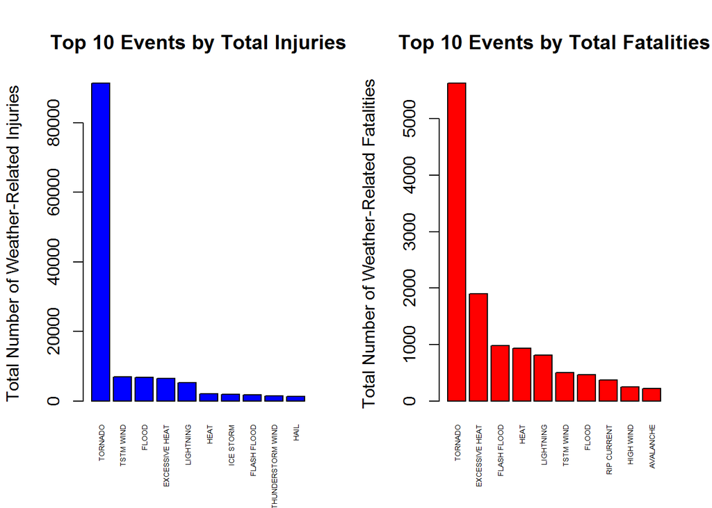

```r
par(mfrow=c(1,2))
barplot(top_10_total_injuries$x, names.arg=top_10_total_injuries$Event, cex.names=0.45, las=3, main="Top 10 Events by Total Injuries", ylab="Total Number of Weather-Related Injuries", col="blue")
barplot(top_10_total_fatalities$x, names.arg=top_10_total_fatalities$Event, cex.names=0.45, las=3, main="Top 10 Events by Total Fatalities", ylab="Total Number of Weather-Related Fatalities", col="red")
```

1. Tornado
2. Heat
3. Flood
4. Lightning
5. wind-related Events

## Weather-Related Events with the Greatest Economic Consequences

The second question that we need to answer is:

2. Across the United States, which types of events have the greatest economic consequences?

We can determine the level of economic impact for various weather-related events by examining the variables related to property damage (PROPDMG) as well as crop damage (CROPDMG) within the original dataset. Additional variables used were PROPDMGEXP and CROPDMGEXP which include exponent of the value in the preceeding variable. For example, “K” correspondes to 1000.

First we need to clean the exponent values and replace them with the proper value. Some values had characters and other were lower or upper case. Others had strange characters (e.g. ?).

```r
#Subsitute CROPDMBGEXP with corresponding numerical value
weather_data$CROPDMGEXP <- sub("[Hh]", "100",weather_data$CROPDMGEXP)
weather_data$CROPDMGEXP <- sub("[Kk]", "1000",weather_data$CROPDMGEXP)
weather_data$CROPDMGEXP <- sub("[Mm]", "1000000",weather_data$CROPDMGEXP)
weather_data$CROPDMGEXP <- sub("[Bb]", "1000000000",weather_data$CROPDMGEXP)
weather_data$CROPDMGEXP <- sub("^$|[-?+]", "0",weather_data$CROPDMGEXP)


#Subsitute PROPDMGEXP with corresponding numerical value
weather_data$PROPDMGEXP <- sub("[Hh]", "100",weather_data$PROPDMGEXP)
weather_data$PROPDMGEXP <- sub("[Kk]", "1000",weather_data$PROPDMGEXP)
weather_data$PROPDMGEXP <- sub("[Mm]", "1000000",weather_data$PROPDMGEXP)
weather_data$PROPDMGEXP <- sub("[Bb]", "1000000000",weather_data$PROPDMGEXP)
weather_data$PROPDMGEXP <- sub("^$|[-?+]", "0",weather_data$PROPDMGEXP)

#convert to numeric
weather_data$CROPDMGEXP <- as.numeric(weather_data$CROPDMGEXP)
weather_data$PROPDMGEXP <- as.numeric(weather_data$PROPDMGEXP)
```

Now we need to multiply both the PROPDMG and CROPDMG by their respective (now cleaned) exponent values.

```r
weather_data$CROPDMG <- weather_data$CROPDMG*weather_data$CROPDMGEXP
weather_data$PROPDMG <- weather_data$PROPDMG*weather_data$PROPDMGEXP
```

We will now get the aggregate sum of both the CROPDMG and PROPDMG values to get a true value of the total amount of economic damage by each event type. We will again get the top 10.

```r
total_damage <- aggregate(weather_data$CROPDMG+weather_data$PROPDMG, list(Event=weather_data$EVTYPE), sum)
top_total_damage <- total_damage[order(total_damage$x, decreasing=TRUE), ]
top_10_total_damage <- head(top_total_damage, 10)
top_10_total_damage
```

```
##                 Event            x
## 170             FLOOD 150319678250
## 411 HURRICANE/TYPHOON  71913712800
## 834           TORNADO  57352114101
## 670       STORM SURGE  43323541000
## 244              HAIL  18758221820
## 153       FLASH FLOOD  17562129187
## 95            DROUGHT  15018672000
## 402         HURRICANE  14610229010
## 590       RIVER FLOOD  10148404500
## 427         ICE STORM   8967041310
```

Next we will create a bar plot illustrating the top 10 most economically impactful weather-related events.

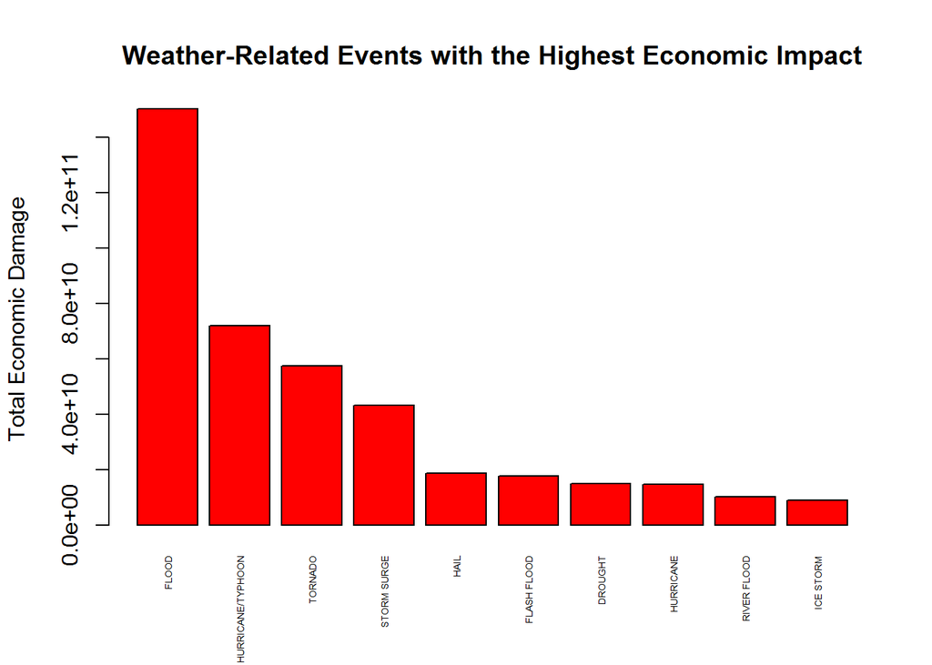

```r
barplot(top_10_total_damage$x, names.arg=top_10_total_damage$Event, ylab="Total Economic Damage", main="Weather-Related Events with the Highest Economic Impact", las=3, col="red", cex.names=0.45)
```

As we can see from the chart above, the top 5 most economically damaging events are as follows:

1. Flood
2. Hurricane
3. Tornado
4. Storm Surge
5. Hail